# Data visualization

### By Saud Alarifi

## Investigation Overview

> Our main goal is to find the features that related directly or indirectly to trip duration .

## Dataset Overview

> The dataset of First quarter of FordGoBike system consist of (312902, 14) rows and columns respectively. .

## Project Timeline

- **Wrangling Process**
- **Univariate Exploration**
- **Bivariate Exploration**
- **Multivariate Exploration**
- **Observed results**
- **Referncees**

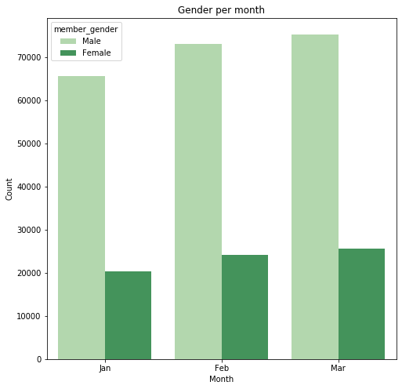

```python
#Clustered Bar chart
plt.figure(figsize = [8, 8])
sb.countplot(data = go_bike_q1[go_bike_q1['member_gender'] != "Other"] , x = 'month', hue = 'member_gender', palette = 'Greens')
plt.xlabel('Month')
plt.ylabel('Count')
plt.title('Gender per month')
```

**Males bikers are more than females bikers in the first quarter.**

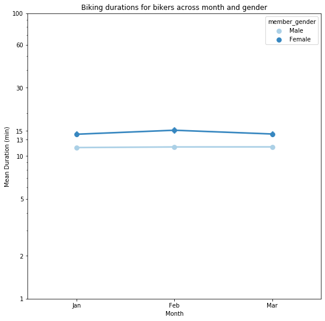

```python
#Point plot for mean duration
fig = plt.figure(figsize = [9,9]);
ax = sb.pointplot(data = go_bike_q1[go_bike_q1['member_gender'] != "Other"] , x = 'month', y = 'duration_min', hue = 'member_gender',
                  palette = 'Blues')
plt.xlabel('Month')
plt.title('Biking durations for bikers across month and gender');
plt.ylabel('Mean Duration (min)');
plt.yscale('log');
plt.yticks([1, 2, 5, 10,  13, 15 , 30, 60 , 100], [1, 2, 5, 10,  13 ,  15 , 30 , 60 , 100]);
```

- **Males have stable duration mean over the first 3 motnhs.**
- **Females spent more duration minutes in Feburary**.
- **On averge , Females spend more duration minutes in a trip than males.**

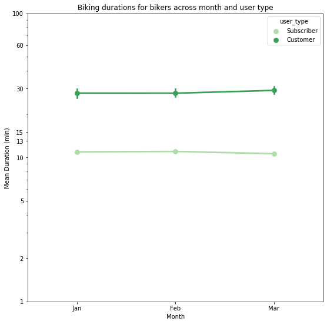

```python
#Point plot for mean duration
fig = plt.figure(figsize = [9,9]);
ax = sb.pointplot(data = go_bike_q1 , x = 'month', y = 'duration_min', hue = 'user_type',
                  palette = 'Greens')
plt.xlabel('Month')
plt.title('Biking durations for bikers across month and user type');
plt.ylabel('Mean Duration (min)');
plt.yscale('log');
plt.yticks([1, 2, 5, 10,  13, 15 , 30, 60 , 100], [1, 2, 5, 10,  13 ,  15 , 30 , 60 , 100]);
```

**The chart above indicates that on averege , Customers spend more minutes on a trip than Subscribers by 160% !.**

## Observed results

- the variables we discussed on this dataset seemed to be strongly independant , in the other hand the interaction between some features seemed to has more effect on each other.
- The majority of bike riders are between 25 to 45 years old.
- There are less bikers in Jan comparing with Mar & Feb. (Seasonality , climate and vacation could be the main reason - need more investigation).
- Males are more likley to bike (Males constitue the majority of the dataset by 74% and females constitue just 25%) despite the fact that females tend to spend more duration per a trip !.
- Customer bikers spend more time riding a bike in comparison of Subscribe bikers.